# BEE552 Biometry Week 2 Lab

Maria Feiler

2/3/2022

## Confidence Intervals

### My Pennies

```r
years <- c(1985, 1989, 2004, 1993, 2021, 2021, 2021, 2012, 2002, 1984)
age <- 2022-years
```

```r
# Number of repeats
nit <- 100

# Matrix to catch samples
bootAge <-  matrix(data = NA,
                   nrow = nit,
                   ncol = length(age),
                   dimnames = list(c(1:nit),
                                   c(1:length(age))
                   )
)

# Vector to catch medians
bootMedAge <- c()

# Collect bootstrap samples of penny ages and calculate medians
for (i in 1:nit) {
        bootAge[i,] <- sample(x = age,
                              size = length(age),
                              replace = TRUE
                              )
        bootMedAge[i] <- median(bootAge[i,])

}
```

```r
# Method 1: Estimate the confidence interval taking the quantiles directly from theta hat star

# Get means of teh boostrap samples
bootAgeMeans <- rowMeans(bootAge)

# Get lower end of the confidence interval
M1thetaLL <- quantile(bootAgeMeans, prob = 0.025)

# Get higher end of confidence interval
M1thetaUL <- quantile(bootAgeMeans, prob = 0.975)
```

```r
# Method 2: Use the Normal approximation to find the confidence interval

# Calculate theta hat
ageThetaHat <- mean(bootAgeMeans)

# Calculate the standard error
sterr <- sd(bootAgeMeans)

# Get lower end of the confidence interval
M2thetaLL <- ageThetaHat - 1.96*sterr

# Get higher end of confidence interval
M2thetaUL <- ageThetaHat + 1.96*sterr
```

Using method 1, there is a 95% chance that the confidence interval (9.64, 27.58) contains the true mean age of pennies in circulation.

Using method 2, there is a 95% chance that the confidence interval (9.78, 27.55) contains the true mean age of pennies in circulation.

**Checkpoint #1**

The confidence intervals are pretty similar to each other.

## Testing Hypotheses Through Permutation

### Carrier Pigeon Flight Speeds

```r
cocks <- c(1359.8, 1355.3, 1355.1, 1353.0, 1349.8, 1348.8, 1345.2)
hens <- c(1357.5, 1356.4, 1355.1, 1353.5, 1353.2, 1352.5, 1350.0, 1349.8, 1346.2, 1344.9, 1344.4, 1343.9, 1342.6)
```

```r
# Calculate the test statistic (mean(cocks) - mean(hens)) to test if cocks and hens fly at different speeds
birdThetaHat <- mean(cocks) - mean(hens)

# Create vector of zeros to compare the sample permutation test statistics against
dif <- integer(1000)

# Create vector of the differences between the sample permutation's means and the null (0)
for (i in 1:length(dif)) {
        samp <- sample(x = c(cocks, hens),
                       replace = FALSE)
        dif[i] <- mean(samp[1:7]) - mean(samp[8:20])
}

p_bird <- sum(abs(dif) > abs(birdThetaHat))/length(dif)
```

The difference between cock and hen flying speeds (p = 0.3) are not statistically significant given a critical value of 0.05.

**Checkpoint #2**

Two-tailed because we’re just seeing if they’re different, which can go either way.

```r
# Number of repeats
nit <- 1000

# Define the matrices into which the cock boostrap and hen bootstrap samples will be stored, and the vector in which the differences between the means will be stored.
bootCocks <- matrix(data = NA,
                nrow = nit,
                ncol = length(cocks),
                dimnames = list(c(1:nit),
                                c(1:length(cocks))
                                )
                )

bootHens <- matrix(data = NA,
                nrow = nit,
                ncol = length(hens),
                dimnames = list(c(1:nit),
                                c(1:length(hens))
                                )
                )
bootDiff <- c()

# Run bootstrap for the number of iterations as defined by nit
for (i in 1:nit) {
    # Collect bootstrap samples for the cocks
        bootCocks[i,] <- sample(x = cocks,
                            size = length(cocks),
                            replace = TRUE
                            )

    # Collect bootstrap samples for the hens
        bootHens[i,] <- sample(x = hens,
                            size = length(hens),
                            replace = TRUE
                            )

    # Collect the difference between the means of the cock and hen bootstrap samples
        bootDiff[i] <- mean(bootCocks[[i]]) - mean(bootHens[[i]])
}

# Difference between cock and hen flying times
CHtheta <- mean(cocks) - mean(hens)

# Get lower end of the confidence interval
CHthetaLL <- quantile(bootDiff, prob = 0.025)

# Get higher end of confidence interval
CHthetaUL <- quantile(bootDiff, prob = 0.975)
```

There is a 95% chance that the confidence interval (-9.9, 15.4) contains the true difference between cock and hen flying speeds.

**Checkpoint #3**

The null hypothesis is that the average flying speeds of cocks and hens are the same, therefore $\overline{Cocks} - \overline{Hens} = 0$.

### Tonsil Size and Virus Carrier Status

|  | Not Enlarged | Enlarged |
| --- | --- | --- |
| Noncarrier | 497 | 560 |
| Carrier | 19 | 29 |

```r
# Define test statistic as the percent of patients that are carriers of the virus for the enlarged and not enlarged tonsils groups
tonsilsTestStat <- (tonsils["Carrier","Not Enlarged"]/sum(tonsils[,"Not Enlarged"])) - (tonsils["Carrier","Enlarged"]/sum(tonsils[,"Enlarged"]))

# Create matrix for the raw data
tonsilsRaw <- matrix(data = NA,
                     nrow = sum(tonsils[,"Enlarged"], tonsils[,"Not Enlarged"]),
                     ncol = 2,
                     dimnames = list(c(1:sum(tonsils[,"Enlarged"], tonsils[,"Not Enlarged"])),
                                     c("Tonsil Size", "Carrier Status")
                                     )
                     )

# Populate matrix using data from the summary tonsils table
tonsilsRaw[,"Tonsil Size"] <- c(rep("Not Enlarged", sum(tonsils[,"Not Enlarged"])),
                                rep("Enlarged", sum(tonsils[,"Enlarged"]))
                                )

tonsilsRaw[,"Carrier Status"] <- c(rep("Carrier", sum(tonsils["Carrier","Not Enlarged"])),
                                   rep("Noncarrier", sum(tonsils["Noncarrier","Not Enlarged"])),
                                   rep("Carrier", sum(tonsils["Carrier","Enlarged"])),
                                   rep("Noncarrier", sum(tonsils["Noncarrier","Enlarged"]))
                                   )

# Create an array to collect new data sets
bootTonsils <- array(data = NA,
                     dim = c(length(tonsilsRaw[,1]),
                             length(tonsilsRaw[1,]),
                             nit),
                     dimnames = list(names(tonsilsRaw[,1]),
                                     names(tonsilsRaw[1,]),
                                     1:nit)
                     )

# nit should still be set to 1000, so 1000 permutations will be conducted
# To get the permutations of this data set, I will randomly sample the tonsil size column, then the carrier status column, then cbind() them together into a new data set permutation. These will be saved into the bootTonsils array

for (i in 1:nit){
        bootTonsils[,,i] <- cbind("Tonsil Size" = sample(x = tonsilsRaw[, "Tonsil Size"],           # Sample tonsil size
                                                         replace = FALSE),
                                  "Carrier Status" = sample(x = tonsilsRaw[, "Carrier Status"],     # Sample carrier status
                                                            replace = FALSE))                       # And bind into array page
}

# Calculate the test statistic for each permutation
# For this loop, the goal is a vector of the differences between the proportion of patients with enlarged tonsils who are ALSO carriers and the proportion of partiets with normal tonsils who are ALSO carriers.
for (i in 1:nit){
        thetaTonsils <- c()
        thetaTonsils[i] <- (sum(as.integer(bootTonsils[,"Carrier Status",i] == "Carrier"         # Subset carriers with
                                           & bootTonsils[,"Tonsil Size",i] == "Enlarged"))       # large tonsils and
                            / sum(as.integer(bootTonsils[,"Tonsil Size",i] == "Enlarged"))       # divide by all enlarged
                            )
                            -                                                                    # Subtracted by...
                           (sum(as.integer(bootTonsils[,"Carrier Status",i] == "Carrier"         # The subset carriers with
                                           & bootTonsils[,"Tonsil Size",i] == "Not Enlarged"))   # normal tonsils and
                            / sum(as.integer(bootTonsils[,"Tonsil Size",i] == "Not Enlarged"))   # divided by all normal
                            )

}

p_tonsils <- sum(abs(thetaTonsils) > abs(tonsilsTestStat))/length(thetaTonsils)
```

**Checkpoint #4**

Given the full data set…

|  | Not Enlarged | Enlarged | Greatly Enlarged |
| --- | --- | --- | --- |
| Noncarrier | 497 | 560 | 269 |
| Carrier | 19 | 29 | 24 |

… I would set the test statistic to be the same as before, just including the greatly enlarged sample into the enlarged. I would do this because I want to see if there is any correlation with enlargement at all. If it was significant, I would test to see if there is a difference in carrier status between the normal and greatly enlarged, then again between the enlarged and greatly enlarged.

## Basics of Bootstrap and Jackknife

```r
# Bootstrap and means
x<-seq(0,9,by=1)
table(sample(x,size=length(x),replace=T))
```

```
##
## 1 2 6 7 8
## 2 2 3 1 2
```

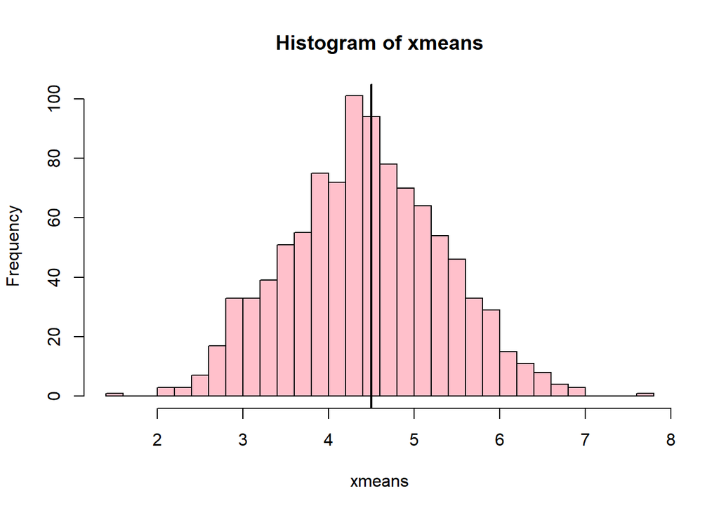

```r
xmeans<-vector(length=1000)

for (i in 1:1000)
  {
  xmeans[i]<-mean(sample(x,replace=T))
  }

hist(xmeans,breaks=30,col="pink")
abline(v=mean(x),lwd=2)
```

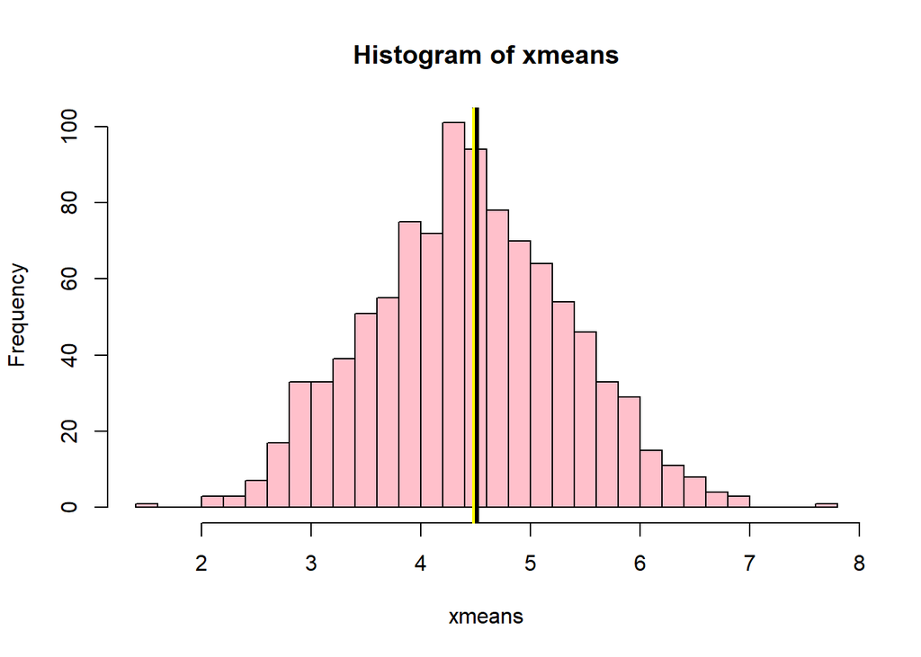

```r
# Bias and standard error
bias.boot<-mean(xmeans)-mean(x)

hist(xmeans,breaks=30,col="pink")
abline(v=mean(x),lwd=5,col="black")
abline(v=mean(xmeans),lwd=2,col="yellow")
```

```r
se.boot<-sd(xmeans)

# Confidence intervals
# Method 1
LL.boot<-mean(xmeans)-1.96*se.boot
UL.boot<-mean(xmeans)+1.96*se.boot

# Method 2
quantile(xmeans,c(0.025,0.975))
```

```
##   2.5%  97.5%
## 2.7975 6.3000
```

```r
# Compare against what we would have gotten through normal distribution theory
se.normal<-sqrt(var(x)/length(x))
LL.normal<-mean(x)-qt(0.975,length(x)-1)*se.normal
UL.normal<-mean(x)+qt(0.975,length(x)-1)*se.normal
```

**Checkpoint #6**